# Modelo Preditivo com Séries Temporais

Previsão do Índice S$P 500 para Julho de 2020

Rodolfo Rissetto Terra - AITendency’s Junior Data Scientist

05-08-2020

```r
#Carregando Packages

needed_libs <- c("psych","ggplot2","pryr","splines",
                 'tidyverse', "sqldf", "lubridate",
                 'zoo','quantmod','xts','moments', "fBasics")

install_missing <- function(lib){
  install.packages(lib,repos="https://cran.r-project.org/", dependencies = TRUE);
  library(lib, character.only = TRUE)}
for (lib in needed_libs)
  tryCatch(library(lib, character.only=TRUE), error = function(e) install_missing(lib))
```

**Objetivo do trabalho:**

Dando sequencia a documentação realizada no dia anterior, descidimos trabalhar com o mesmo índice S&P 500, porém de uma forma diferente, como trabalhando no dia anterior.

**Metodologia:**

Coforme a documentação demonstrado no dia anterior, captamos a TS, utilizando a função **getSymbols** do páckage quantmod, para coler dados históricos do índice SPY (S&P 500).

Porém para o estudo no dia de hoje, não iremos trabalhar com o Dataset em formato TS, mas em formato Data Frame, e trabalharemos com o package **Splines**, para prever o valor do índice a um tempo futuro.

```r
getSymbols("SPY", from = "2008-01-01", to = "2009-03-01", auto.assing = T)
```

```
## [1] "SPY"
```

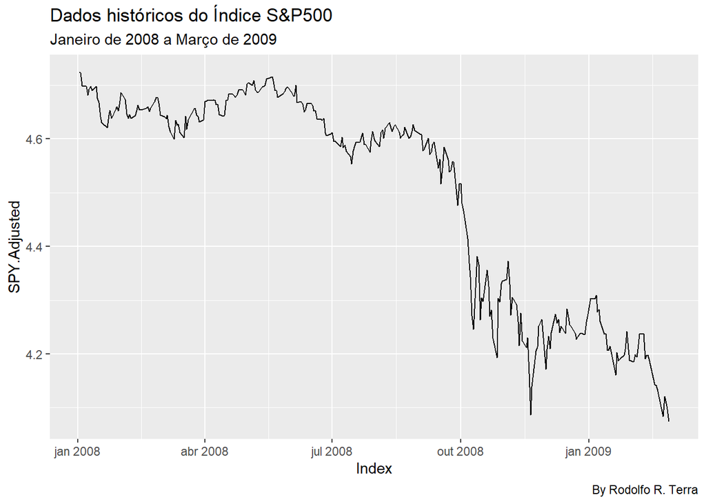

```r
#Aplicando o log e plotando para conseguirmos realizar a previsão
#a partir de outubro de 2008

autoplot(log(SPY$SPY.Adjusted)) +
labs(xlab("Ano"),
     ylab("Log do Índice"),
     title = "Dados históricos do Índice S&P500",
     subtitle = "Janeiro de 2008 a Março de 2009",
     caption = "By Rodolfo R. Terra")
```

## Primeiro Modelo

Primeiramente pegaremos apenas o período de janeiro a outubro de 2008, como é dados histórico, criaremos um modelo para prever o índice após 60 dias, ou seja, dia primeiro de Dezembro de 2008. e iremos comparar o resultado e a sua acurácia.

```r
getSymbols("SPY", from = "2008-01-01", to = "2008-10-01", auto.assing = T)
```

```
## [1] "SPY"
```

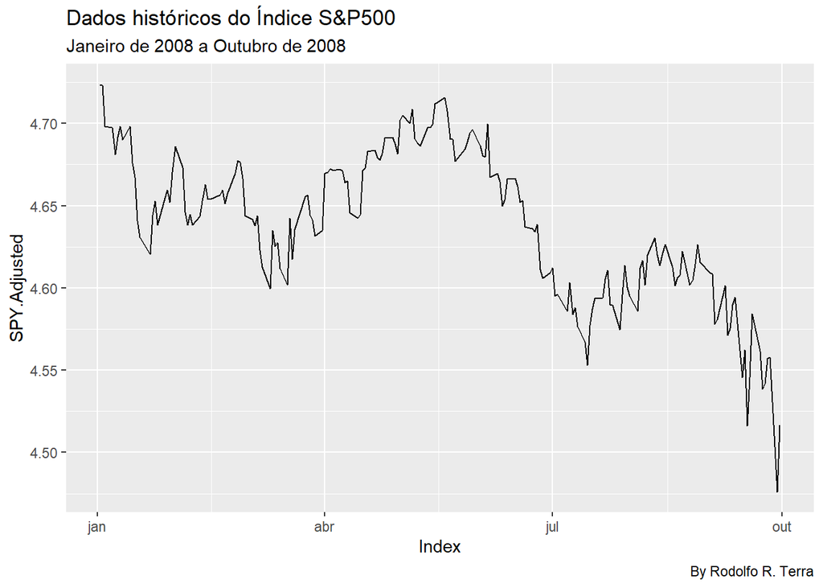

```r
autoplot(log(SPY$SPY.Adjusted)) +
  labs(xlab("Ano"),
       ylab("Log do Índice"),
       title = "Dados históricos do Índice S&P500",
       subtitle = "Janeiro de 2008 a Outubro de 2008",
       caption = "By Rodolfo R. Terra")
```

```r
df <- as.data.frame(log(SPY$SPY.Adjusted))
df1 <- df$SPY.Adjusted

# Capiturar os index
df2 <- as.data.frame(row.names(df))

#junta nem um único Data Frame
df <- cbind(df2, df1)

colnames(df) <- c("data","log_ind")
head(df)
```

|  | data | log_ind |
| --- | --- | --- |
| 1 | 2008-01-02 | 4.723736 |
| 2 | 2008-01-03 | 4.723253 |
| 3 | 2008-01-04 | 4.698441 |
| 4 | 2008-01-07 | 4.697591 |
| 5 | 2008-01-08 | 4.681311 |
| 6 | 2008-01-09 | 4.691766 |

```r
str(df)
```

```
## 'data.frame':    189 obs. of  2 variables:
##  $ data   : Factor w/ 189 levels "2008-01-02","2008-01-03",..: 1 2 3 4 5 6 7 8 9 10 ...
##  $ log_ind: num  4.72 4.72 4.7 4.7 4.68 ...
```

```r
# Usando Spline

fit <- smooth.spline(df$data, df$log_ind, df = 20)

fit
```

```
## Call:
## smooth.spline(x = df$data, y = df$log_ind, df = 20)
##
## Smoothing Parameter  spar= 0.5719209  lambda= 2.276572e-05 (13 iterations)
## Equivalent Degrees of Freedom (Df): 19.99771
## Penalized Criterion (RSS): 0.03067319
## GCV: 0.0002029717
```

```r
x<- df$log_ind

means <- data.frame(x)

means$y <- predict(fit, means$x)$y

predict(fit, 20)$y
```

```
## [1] 4.652494
```

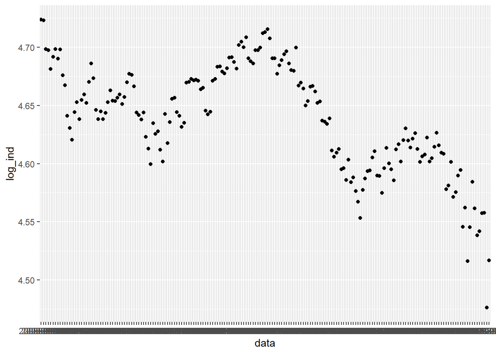

```r
# Função

f <- function(x){
  return(predict(fit,x)$y)
}


#Plotar o gráfico com a função Spline

ggplot() +
  geom_point(data = df, aes(x=data, y = log_ind))
```

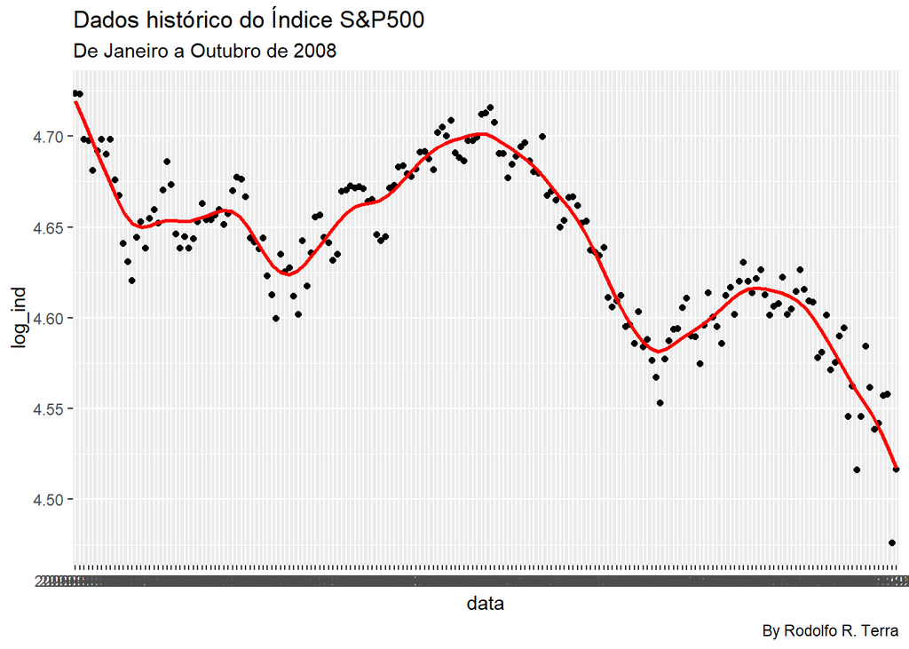

```r
ggplot() +
  geom_point(data = df, aes(x=data, y = log_ind)) +
  stat_function(data=data.frame(x=c(1,189)), aes(x=x), fun=f,
                color="red", lwd = 1) +
  labs(xlab ="Índice Diário",
       ylab = "Log do Índice",
       title = "Dados histórico do Índice S&P500",
       subtitle = "De Janeiro a Outubro de 2008",
       caption = "By Rodolfo R. Terra")
```

Conforme podemos observar o gráfico acima, a curva em vermelho, é o modelo criado. Porém ela ainda não está prevendo novos valores.

Simplesmente ele está criando tendências nos dados já fornecidos, que são de janeiro a outubro de 2008.

Abaixo iremos criar o mesmo dados, com a previsão do índice para primeiro de Dezembro de 2008.

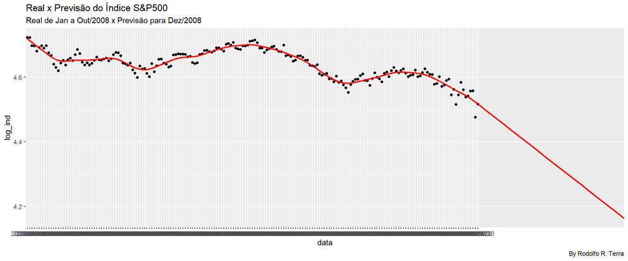

```r
ggplot() +
  geom_point(data = df, aes(x=data, y = log_ind)) +
  stat_function(data=data.frame(x=c(1,250)), aes(x=x), fun=f,
                color="red", lwd = 1) +
  labs(xlab ="Índice Diário",
       ylab = "Log do Índice",
       title = "Real x Previsão do Índice S&P500",
       subtitle = "Real de Jan a Out/2008 x Previsão para Dez/2008",
       caption = "By Rodolfo R. Terra")
```

```r
getSymbols("SPY", from = "2008-01-01", to = "2008-12-01", auto.assing = T)
```

```
## [1] "SPY"
```

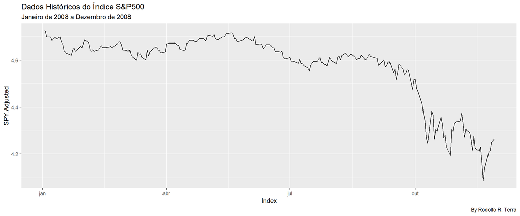

```r
autoplot(log(SPY$SPY.Adjusted)) +
  labs(xlab("Ano"),
       ylab("Log do Índice"),
       title = "Dados Históricos do Índice S&P500",
       subtitle = "Janeiro de 2008 a Dezembro de 2008",
       caption = "By Rodolfo R. Terra")
```

```r
# Valor previsto log do índice para 01 de Dezzembro de 2008
predict(fit, 250)$y
```

```
## [1] 4.162902
```

```r
# Valor do índice ajustada aplicando o Antilog para 01 de Dezembro de 2008.
exp(predict(fit, 250)$y)
```

```
## [1] 64.25772
```

```r
getSymbols("SPY", from = "2008-12-01", to = "2008-12-02", auto.assing = T)
```

```
## [1] "SPY"
```

```r
log(SPY$SPY.Adjusted)
```

```
##            SPY.Adjusted
## 2008-12-01     4.171244
```

Abaixo mostraremo o gráfico das informações histórica de setembro a Dezembro de 2008.

```r
getSymbols("SPY", from = "2008-09-01", to = "2008-12-02", auto.assing = T)
```

```
## [1] "SPY"
```

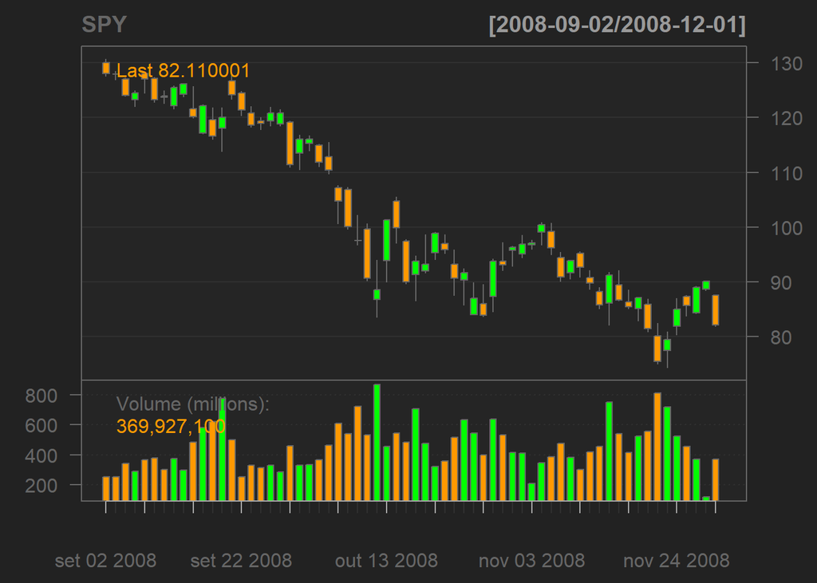

```r
chartSeries(SPY)
```

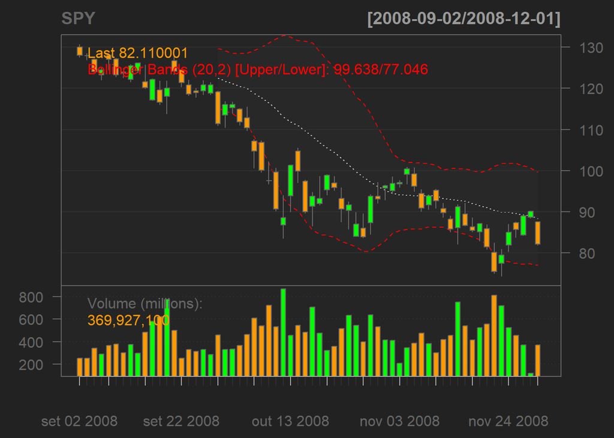

```r
addBBands()
```

## Segundo Modelo

Agora faremos o mesmo modelo porém dos índices de Janeiro de 2019 a Maio de 2020. O objetivo agora é prever o índice de julho de 2020.

```r
getSymbols("SPY", from = "2019-01-01", auto.assing = T)
```

```
## [1] "SPY"
```

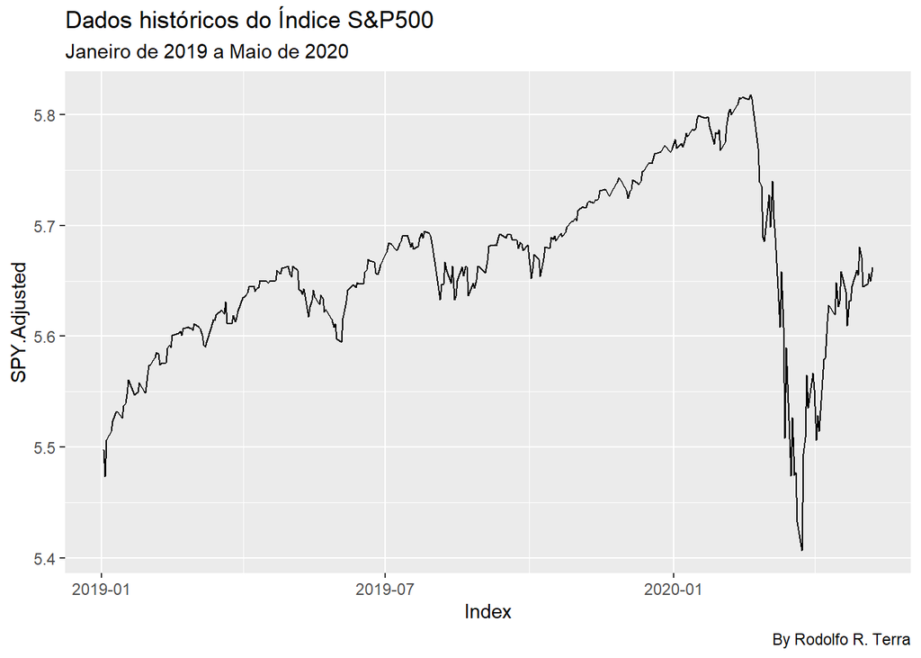

```r
autoplot(log(SPY$SPY.Adjusted)) +
  labs(xlab("Ano"),
       ylab("Log do Índice"),
       title = "Dados históricos do Índice S&P500",
       subtitle = "Janeiro de 2019 a Maio de 2020",
       caption = "By Rodolfo R. Terra")
```

```r
df <- as.data.frame(log(SPY$SPY.Adjusted))
df1 <- df$SPY.Adjusted

# Capiturar os index
df2 <- as.data.frame(row.names(df))

#junta nem um único Data Frame
df <- cbind(df2, df1)

colnames(df) <- c("data","log_ind")
head(df)
```

|  | data | log_ind |
| --- | --- | --- |
| 1 | 2019-01-02 | 5.497559 |
| 2 | 2019-01-03 | 5.473407 |
| 3 | 2019-01-04 | 5.506354 |
| 4 | 2019-01-07 | 5.514207 |
| 5 | 2019-01-08 | 5.523559 |
| 6 | 2019-01-09 | 5.528222 |

```r
tail(df)
```

|  | data | log_ind |
| --- | --- | --- |
| 335 | 2020-04-30 | 5.671535 |
| 336 | 2020-05-01 | 5.644705 |
| 337 | 2020-05-04 | 5.647459 |
| 338 | 2020-05-05 | 5.656656 |
| 339 | 2020-05-06 | 5.649854 |
| 340 | 2020-05-07 | 5.661849 |

```r
str(df)
```

```
## 'data.frame':    340 obs. of  2 variables:
##  $ data   : Factor w/ 340 levels "2019-01-02","2019-01-03",..: 1 2 3 4 5 6 7 8 9 10 ...
##  $ log_ind: num  5.5 5.47 5.51 5.51 5.52 ...
```

```r
# Usando Spline

fit <- smooth.spline(df$data, df$log_ind, df = 10)

fit
```

```
## Call:
## smooth.spline(x = df$data, y = df$log_ind, df = 10)
##
## Smoothing Parameter  spar= 0.7844663  lambda= 0.0008164846 (11 iterations)
## Equivalent Degrees of Freedom (Df): 9.99883
## Penalized Criterion (RSS): 0.3584608
## GCV: 0.001119153
```

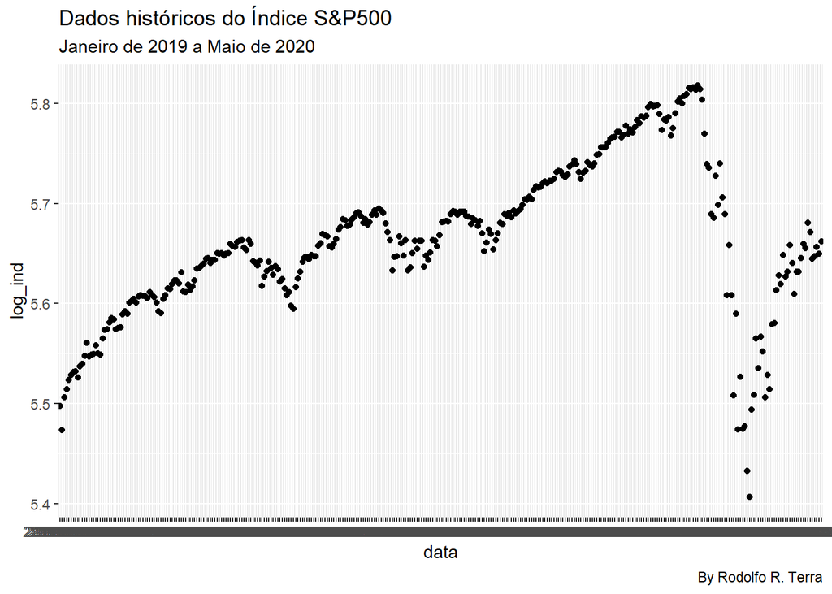

```r
x<- df$log_ind

means <- data.frame(x)

means$y <- predict(fit, means$x)$y


# Função

f <- function(x){
  return(predict(fit,x)$y)
}


#Plotar o gráfico com a função Spline

ggplot() +
  geom_point(data = df, aes(x=data, y = log_ind)) +
                 labs(xlab("Ano"),
       ylab("Log do Índice"),
       title = "Dados históricos do Índice S&P500",
       subtitle = "Janeiro de 2019 a Maio de 2020",
       caption = "By Rodolfo R. Terra")
```

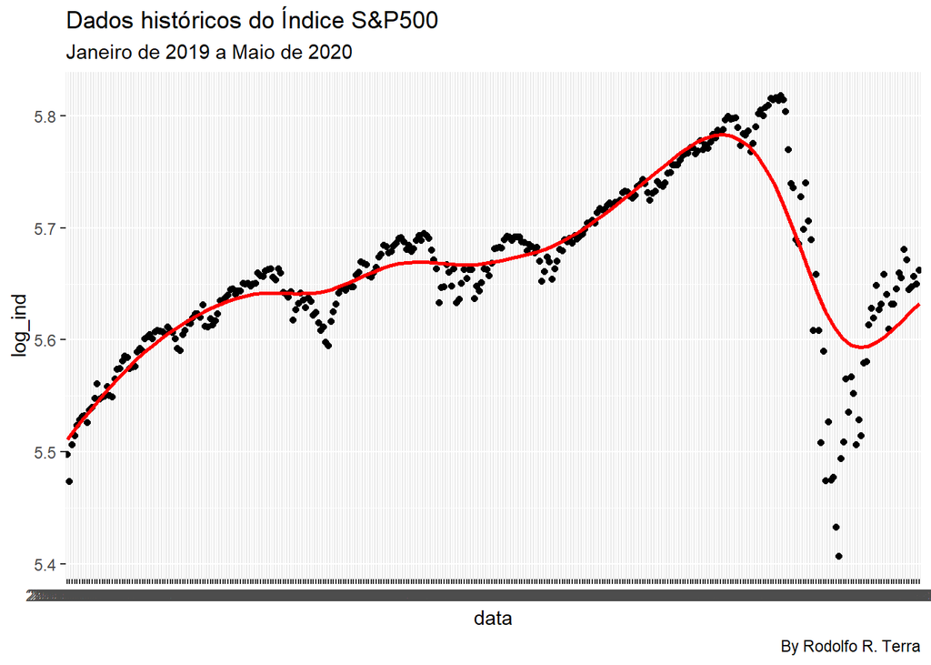

```r
ggplot() +
  geom_point(data = df, aes(x=data, y = log_ind)) +
  stat_function(data=data.frame(x=c(1,340)), aes(x=x), fun=f,
                color="red", lwd = 1) +
  labs(xlab("Ano"),
       ylab("Log do Índice"),
       title = "Dados históricos do Índice S&P500",
       subtitle = "Janeiro de 2019 a Maio de 2020",
       caption = "By Rodolfo R. Terra")
```

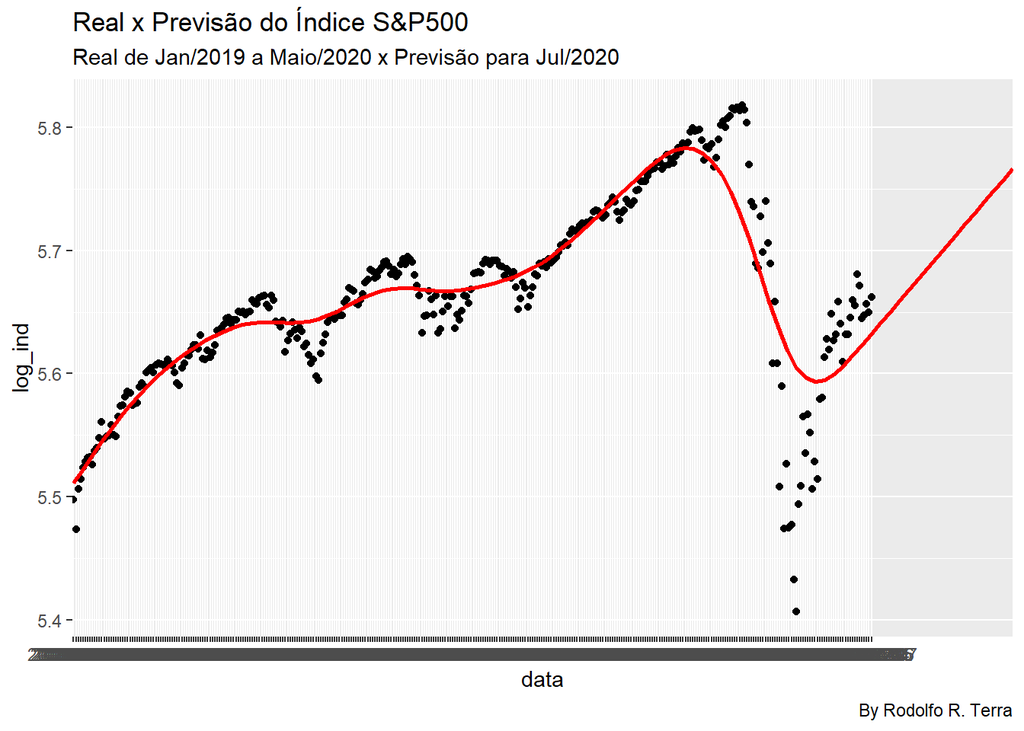

```r
ggplot() +
  geom_point(data = df, aes(x=data, y = log_ind)) +
  stat_function(data=data.frame(x=c(1,400)), aes(x=x), fun=f,
                color="red", lwd = 1) +
  labs(xlab("Ano"),
       ylab("Log do Índice"),
       title = "Real x Previsão do Índice S&P500",
       subtitle = "Real de Jan/2019 a Maio/2020 x Previsão para Jul/2020",
       caption = "By Rodolfo R. Terra")
```

```r
predict(fit, 400)$y
```

```
## [1] 5.766527
```

Conforme podemos observar no Gráfico acima, o modelo não consegui estimar a queda que ocorreu durante o começo desse ano.

Porém ele estimou para julho de 2020 um log do índice de 5.766.

Abaixo iremos alterar os parâmetros do **fit()** e realizar um novo modelo fazendo com que o modelo abrenda mais nforme o passar do tempo e iremos comparar os índices.

passando do parâmtero:

fit <- smooth.spline(df$data, df$log_ind, **df = 10)**

Para:

fit <- smooth.spline(df$data, df$log_ind, **df = 100)**

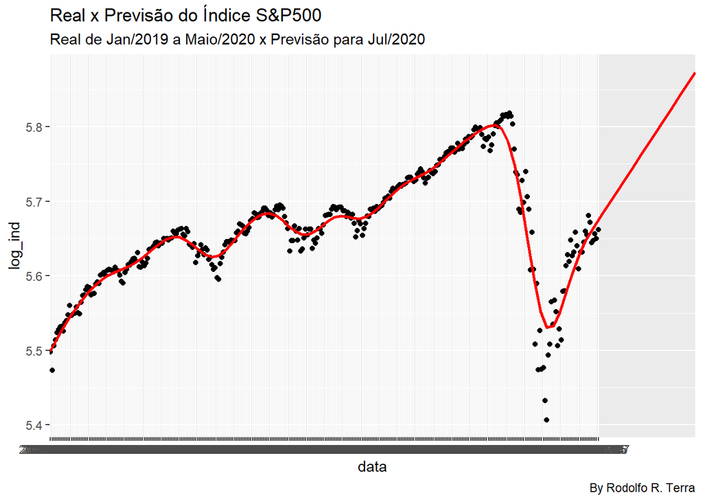

```r
# Usando Spline

fit <- smooth.spline(df$data, df$log_ind, df = 20)

ggplot() +
  geom_point(data = df, aes(x=data, y = log_ind)) +
  stat_function(data=data.frame(x=c(1,400)), aes(x=x), fun=f,
                color="red", lwd = 1) +
  labs(xlab("Ano"),
       ylab("Log do Índice"),
       title = "Real x Previsão do Índice S&P500",
       subtitle = "Real de Jan/2019 a Maio/2020 x Previsão para Jul/2020",
       caption = "By Rodolfo R. Terra")
```

```r
predict(fit, 400)$y
```

```
## [1] 5.873375
```

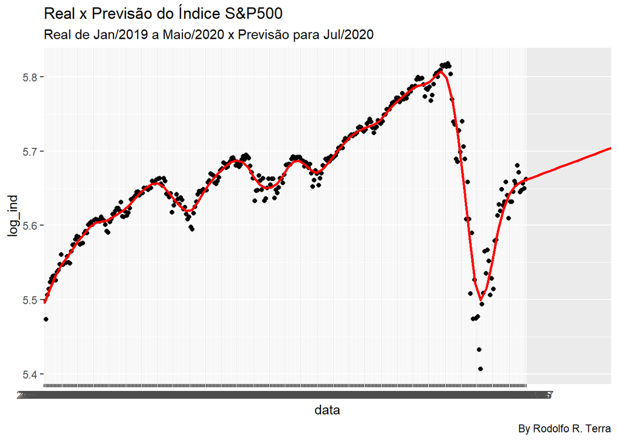

```r
fit <- smooth.spline(df$data, df$log_ind, df = 30)

ggplot() +
  geom_point(data = df, aes(x=data, y = log_ind)) +
  stat_function(data=data.frame(x=c(1,400)), aes(x=x), fun=f,
                color="red", lwd = 1) +
  labs(xlab("Ano"),
       ylab("Log do Índice"),
       title = "Real x Previsão do Índice S&P500",
       subtitle = "Real de Jan/2019 a Maio/2020 x Previsão para Jul/2020",
       caption = "By Rodolfo R. Terra")
```

```r
predict(fit, 400)$y
```

```
## [1] 5.704396
```

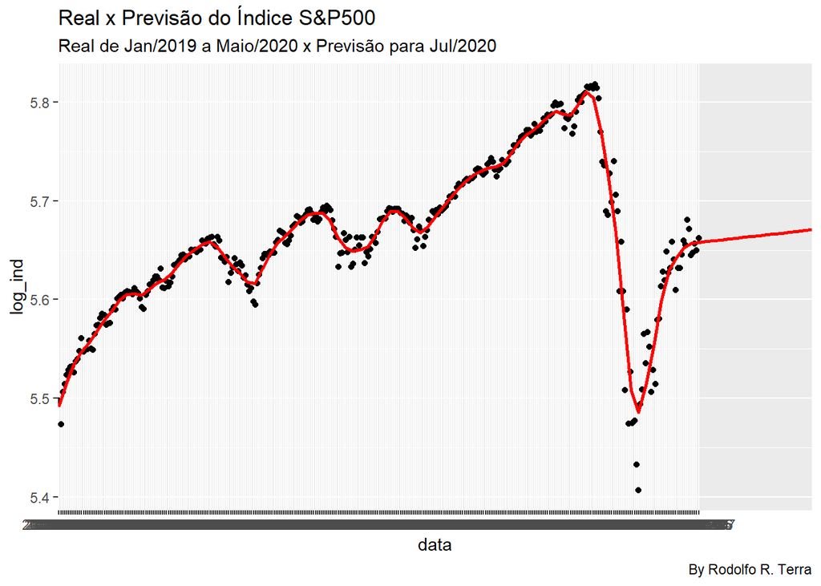

```r
fit <- smooth.spline(df$data, df$log_ind, df = 40)

ggplot() +
  geom_point(data = df, aes(x=data, y = log_ind)) +
  stat_function(data=data.frame(x=c(1,400)), aes(x=x), fun=f,
                color="red", lwd = 1) +
  labs(xlab("Ano"),
       ylab("Log do Índice"),
       title = "Real x Previsão do Índice S&P500",
       subtitle = "Real de Jan/2019 a Maio/2020 x Previsão para Jul/2020",
       caption = "By Rodolfo R. Terra")
```

```r
predict(fit, 400)$y
```

```
## [1] 5.670712
```

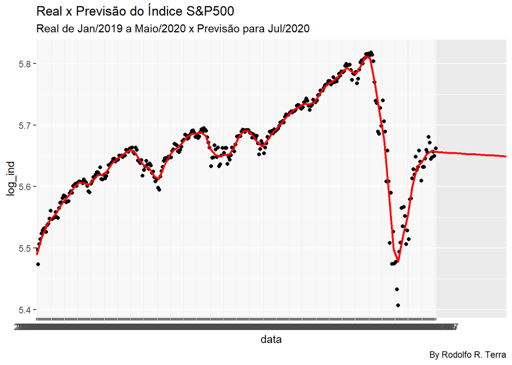

```r
fit <- smooth.spline(df$data, df$log_ind, df = 50)

ggplot() +
  geom_point(data = df, aes(x=data, y = log_ind)) +
  stat_function(data=data.frame(x=c(1,400)), aes(x=x), fun=f,
                color="red", lwd = 1) +
  labs(xlab("Ano"),
       ylab("Log do Índice"),
       title = "Real x Previsão do Índice S&P500",
       subtitle = "Real de Jan/2019 a Maio/2020 x Previsão para Jul/2020",
       caption = "By Rodolfo R. Terra")
```

```r
predict(fit, 400)$y
```

```
## [1] 5.649296
```

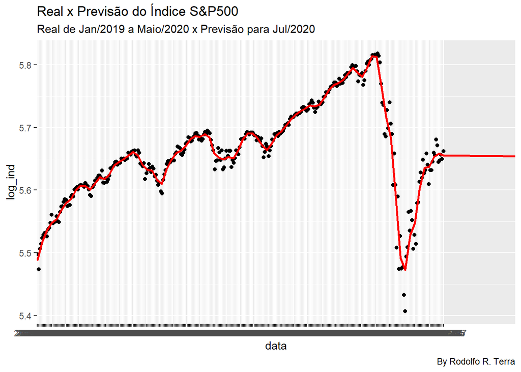

```r
fit <- smooth.spline(df$data, df$log_ind, df = 60)

ggplot() +
  geom_point(data = df, aes(x=data, y = log_ind)) +
  stat_function(data=data.frame(x=c(1,400)), aes(x=x), fun=f,
                color="red", lwd = 1) +
  labs(xlab("Ano"),
       ylab("Log do Índice"),
       title = "Real x Previsão do Índice S&P500",
       subtitle = "Real de Jan/2019 a Maio/2020 x Previsão para Jul/2020",
       caption = "By Rodolfo R. Terra")
```

```r
predict(fit, 400)$y
```

```
## [1] 5.654119
```

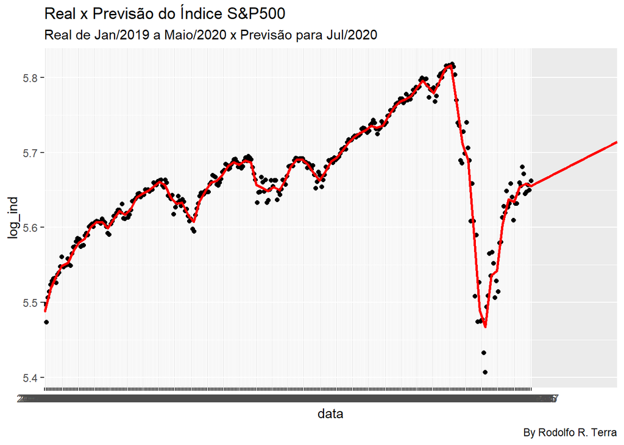

```r
fit <- smooth.spline(df$data, df$log_ind, df = 70)

ggplot() +
  geom_point(data = df, aes(x=data, y = log_ind)) +
  stat_function(data=data.frame(x=c(1,400)), aes(x=x), fun=f,
                color="red", lwd = 1) +
  labs(xlab("Ano"),
       ylab("Log do Índice"),
       title = "Real x Previsão do Índice S&P500",
       subtitle = "Real de Jan/2019 a Maio/2020 x Previsão para Jul/2020",
       caption = "By Rodolfo R. Terra")
```

```r
predict(fit, 400)$y
```

```
## [1] 5.714116
```

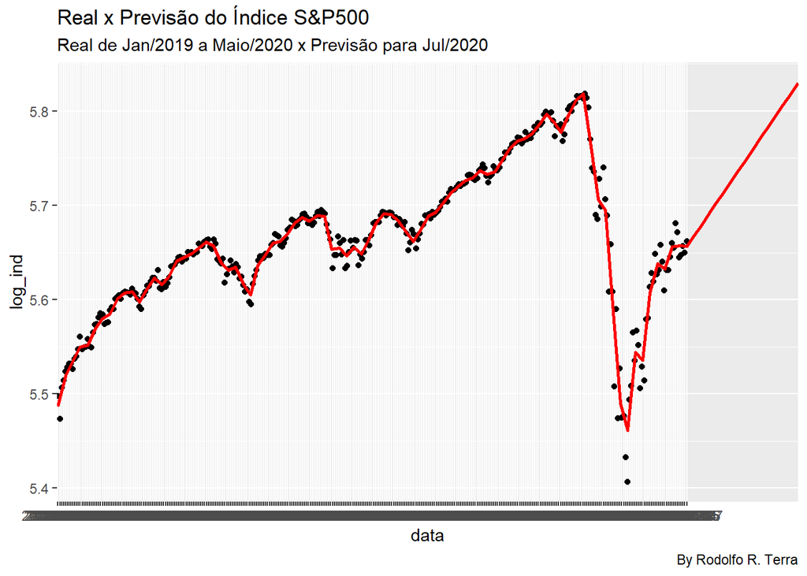

```r
fit <- smooth.spline(df$data, df$log_ind, df = 80)

ggplot() +
  geom_point(data = df, aes(x=data, y = log_ind)) +
  stat_function(data=data.frame(x=c(1,400)), aes(x=x), fun=f,
                color="red", lwd = 1) +
  labs(xlab("Ano"),
       ylab("Log do Índice"),
       title = "Real x Previsão do Índice S&P500",
       subtitle = "Real de Jan/2019 a Maio/2020 x Previsão para Jul/2020",
       caption = "By Rodolfo R. Terra")
```

```r
predict(fit, 400)$y
```

```
## [1] 5.83004
```

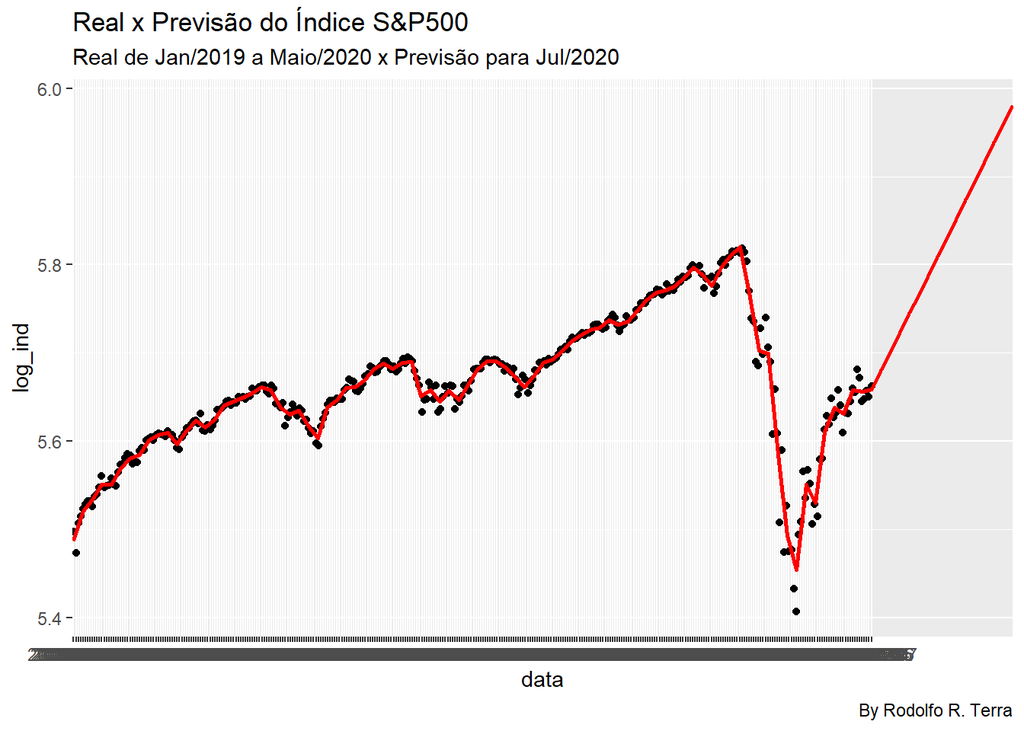

```r
fit <- smooth.spline(df$data, df$log_ind, df = 90)

ggplot() +
  geom_point(data = df, aes(x=data, y = log_ind)) +
  stat_function(data=data.frame(x=c(1,400)), aes(x=x), fun=f,
                color="red", lwd = 1) +
  labs(xlab("Ano"),
       ylab("Log do Índice"),
       title = "Real x Previsão do Índice S&P500",
       subtitle = "Real de Jan/2019 a Maio/2020 x Previsão para Jul/2020",
       caption = "By Rodolfo R. Terra")
```

```r
predict(fit, 400)$y
```

```
## [1] 5.981243
```

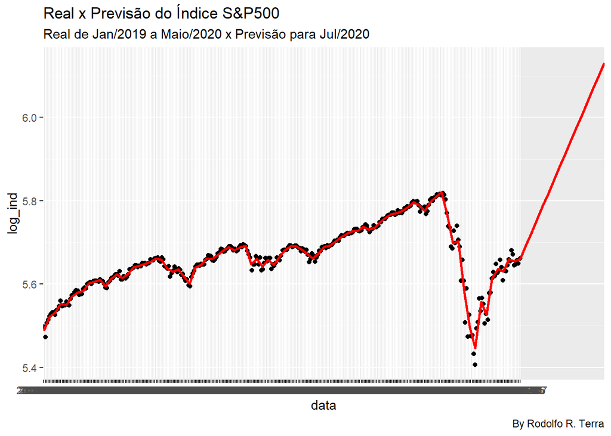

```r
fit <- smooth.spline(df$data, df$log_ind, df = 100)

ggplot() +
  geom_point(data = df, aes(x=data, y = log_ind)) +
  stat_function(data=data.frame(x=c(1,400)), aes(x=x), fun=f,
                color="red", lwd = 1) +
  labs(xlab("Ano"),
       ylab("Log do Índice"),
       title = "Real x Previsão do Índice S&P500",
       subtitle = "Real de Jan/2019 a Maio/2020 x Previsão para Jul/2020",
       caption = "By Rodolfo R. Terra")
```

```r
predict(fit, 400)$y
```

```
## [1] 6.131708
```

Conforme podemos observar nos gráficos acimas, conforme iremos aumentando gradativamente em um intervalo de 10 o parâmetro **df**, a estimativa do índice até 50 tende a crescer, porém diminuindo o seu grau de amplitura, chegando ao df = 50, praticamente ele demonstra uma tendência de queda novamente no índice, podendo perceber que existe uma barreira de têndência contrária.

Porém a partir de df maiores de 60, o modelo mostra novamente uma tendência de alta, acreditando em continuar elevandos o índice.

Ao estudar um pouco mercado de ações, podemos observar nos ultimos dias, que já existe uma agromeração de valores em uma mesma área da região plotada, isso significa que as forças entre compradores e vendedores, estão se igualando, possívelmente, irá ocorrer uma queda de resistencia para baixo, então conforme esse modelo os melhores parâmtero para o df estão entre 50 e 60, que resulta um log do índice para julho de 2020 de 5.649296 ou 5.654119, respectivamnete.

## **Conclusão:**

Conforme podemos acompanhar os noticiários e a epidemia tanto Americana como os outros países, o estudo iniciado ontem, partimos do príncípio de consegui atingir um modelo preditivo que nós dê uma queda, ou pelo menos um bechmark que possamos acompanhar como um norte.

Vejamos o modelo com o índice S&P 500, não demonstrou em nenhum dos modelos previsto para julho de 2020, uma força tendência de queda. O que conseguimos foi apenas uma estagnação no crescimento.

Com esses gráficos, e o estudo desenvolvido entre o dia anterior e hoje, nos leva a três possibilidades:

**a)** Comparada ao índice das 500 maiores empresas americanas, podemos pressupor, que mesmo em crise a economia Norte Americana, está querendo voltar a reagir, e irá voltar a crescer, ou não irá mais cair, podendo não atingir grandes crescimentos em 2020, mas se estagnar em um 5.6 a 6.0.

Partindo nessa hipótese, temos que ser otmistas e criarmos modelos enxutos, mas não se preocupando com a diminuição da estrutura empresarial de cada organização, mas na conservação da estrutura atual, e da não extrapolação de gastos, na receita, sem necessidades.

**b)** Acreditando em um cenário pessimista, e em toda a mída com noticiário, talvéz o índice S&P 500, possa não ter sido uma boa escolha para criar uma métrica de tendência para o segundo semestre de 2020 e precisaremos estudar outros índices, para observar a sua reação histórica e principalmente do primeiro semestre de 2020 como por exemplo índices de:

- Energia Elétrica;
- Logística;
- Escolaridade de ensino superior;
- Taxa de mortalidade;
- Desemprego;
- Comércio de Varajo.
- E-commerce;
- Entre outros.

**c)** Ou podemos também suspeitar do modelo, e derrepente o package **slines** não seja o mais adequado para o cenário atual.

Abaixo, mostraremos mais uma vês, o índice S$P 500 de janeiro de 2019 a Maio de 2020.

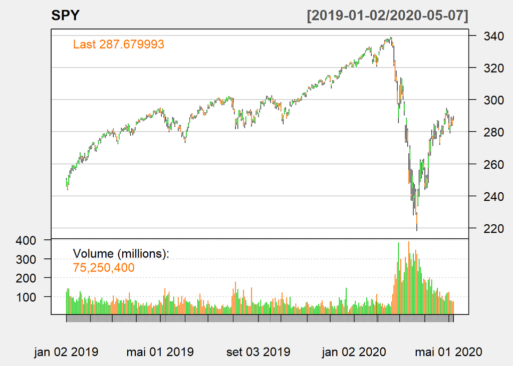

```r
chartSeries(SPY, theme = "white" )
```

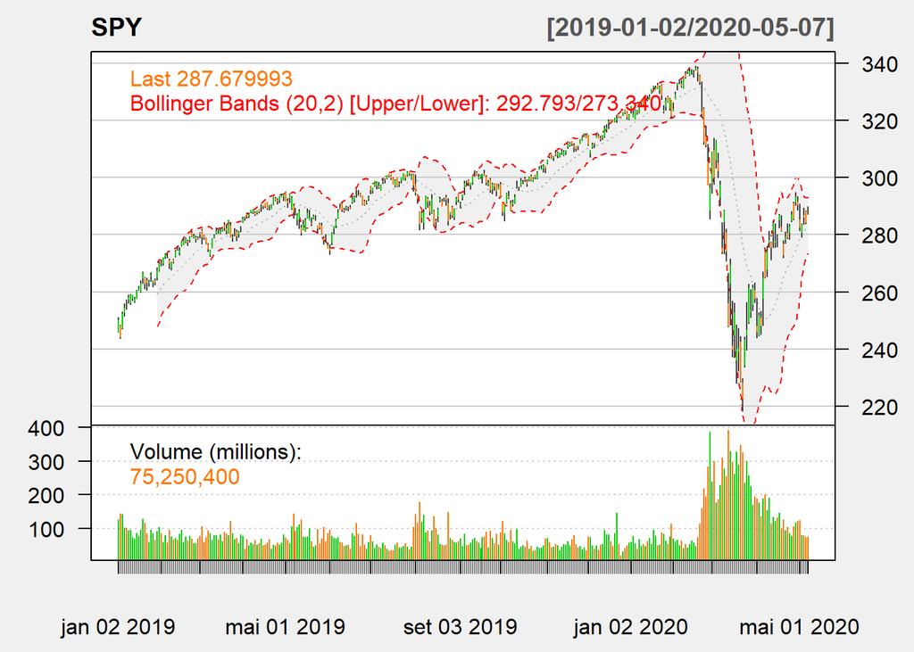

```r
addBBands()
```

**E-mail:** consultoriaterra@hotmail.com